# HW1_IE360

## HOMEWORK 1

In this homework, data visualization is done and data correlation is observed. Chosen data sets are Car Sales, Euro Exchange Rate, Vehicle Loans, Vehicle Consumer Price Index. Car Sales data is derived from https://www.odd.org.tr/web_2837_1/neuralnetwork.aspx?type=35 While rest of sets is obtained from https://evds2.tcmb.gov.tr/ Related key words search is done from Google Trends. Related box plot, correlation plot, correlation calculations are done to be able to make interpretation.

### INTRODUCTION

Vehicles are known as property that people prioritize generally right after buying house or sometimes the opposite is the case. With the increase in technology and manufacturing techniques, production of vehicles is being done not only in abroad but also in Turkey. Despite of the increase in the local production, small parts of the vehicles come from abroad which makes its price dependent to exchange rate. Therefore, changes in exchange rate have an effect on the vehicle prices which contribute to the number of vehicles sold in a period. Changes in the prices of goods and services are referred as inflation, which is basically decrease in the purchasing power of money. Customer price index is one of the ways of measuring inflation over a given period. Customer price index for vehicles shows the changes in the prices of the vehicles. Increasing trend of the vehicles’ price can be shown by CPI.

With the increasing price level, people consider banks as a solution. Banks are the situations whose working principle is basically giving money to the customer right now and taking it back later with some interest rate. This enables customer, who is willing to buy something with the money they do not have at that moment, to buy that product. Banks have loan types for specific products such as housing loans, vehicle loans and so on. This is highly preferred way of buying relatively high valued products such as vehicle. Due to the fact that buying a vehicle with increased price level without any money support is not that easy, taking a loan from a bank is a popular solution. Therefore, it may be suggested that, number of vehicles sold in a period is somehow related to amount of vehicle credit taken as well as changes in exchange rate.

The research question can be stated as “Are there any correlation between sales amount of vehicles, CPI of vehicles, the total amount of credits taken and Euro Exchange Rate(TRY)?”

At the end, correlations between data sets and the amount of key word search obtained from Google Trend will be examined.

### Required Libraries

```r
library(ggplot2,warn.conflicts=F, quietly=T)
library(xts,warn.conflicts=F, quietly=T)
library(ggcorrplot,warn.conflicts=F, quietly=T)
library("readxl",warn.conflicts=F, quietly=T)
library(data.table,warn.conflicts=F, quietly=T)
library(lubridate,warn.conflicts=F, quietly=T)
library(ggplot2,warn.conflicts=F, quietly=T)
library(readxl,warn.conflicts=F, quietly=T)
library(dplyr,warn.conflicts=F, quietly=T)
library(GGally,warn.conflicts=F, quietly=T)
library(zoo,warn.conflicts=F, quietly=T)
```

### DATA DERIVATION

Data is deriven from the excel file and necessary changes have been made. All data set has year and month columns and also related values.

```r
setwd("/Users/gozdeaygun/Desktop")
Vehicle_sale = read_xlsx("Vehicle_Sales.xlsx")
Vehicle_loan = read_xlsx("Vehicle_loan.xlsx")
Price_index=read_xlsx("Price_index.xlsx")
Euro_rate=read_xlsx("Euro_rate.xlsx")

Vehicle_sale$Tarih = as.Date(as.yearmon(Vehicle_sale$Tarih))
Vehicle_sale$Month = month(Vehicle_sale$Tarih)
Vehicle_sale$Year <- factor(format(x = Vehicle_sale$Tarih, format = "%Y"), ordered = TRUE)

Vehicle_loan$Tarih = as.Date(as.yearmon(Vehicle_loan$Tarih))
Vehicle_loan$Month = month(Vehicle_loan$Tarih)
Vehicle_loan$Year <- factor(format(x = Vehicle_loan$Tarih, format = "%Y"), ordered = TRUE)

Price_index$Tarih = as.Date(as.yearmon(Price_index$Tarih))
Price_index$Month = month(Price_index$Tarih)
Price_index$Year <- factor(format(x = Price_index$Tarih, format = "%Y"), ordered = TRUE)

Euro_rate$Tarih = as.Date(as.yearmon(Euro_rate$Tarih))
Euro_rate$Month = month(Euro_rate$Tarih)
Euro_rate$Year <- factor(format(x = Euro_rate$Tarih, format = "%Y"), ordered = TRUE)

allTogether=rbind(Vehicle_sale,Vehicle_loan,Price_index,Euro_rate)
```

### DATA VISUALIZATION

Histograms and boxplots of the data is drawn to be able to anaylze data.

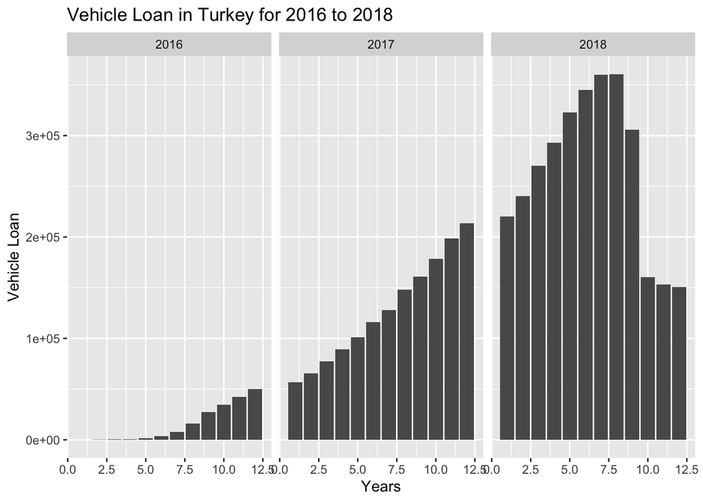

```r
ggplot(Vehicle_loan,aes(x=Month,y=values))+ geom_bar(stat='identity')+
  facet_wrap(~year(Tarih))+
  xlab("Years") + ylab("Vehicle Loan")+ ggtitle("Vehicle Loan in Turkey for 2016 to 2018")
```

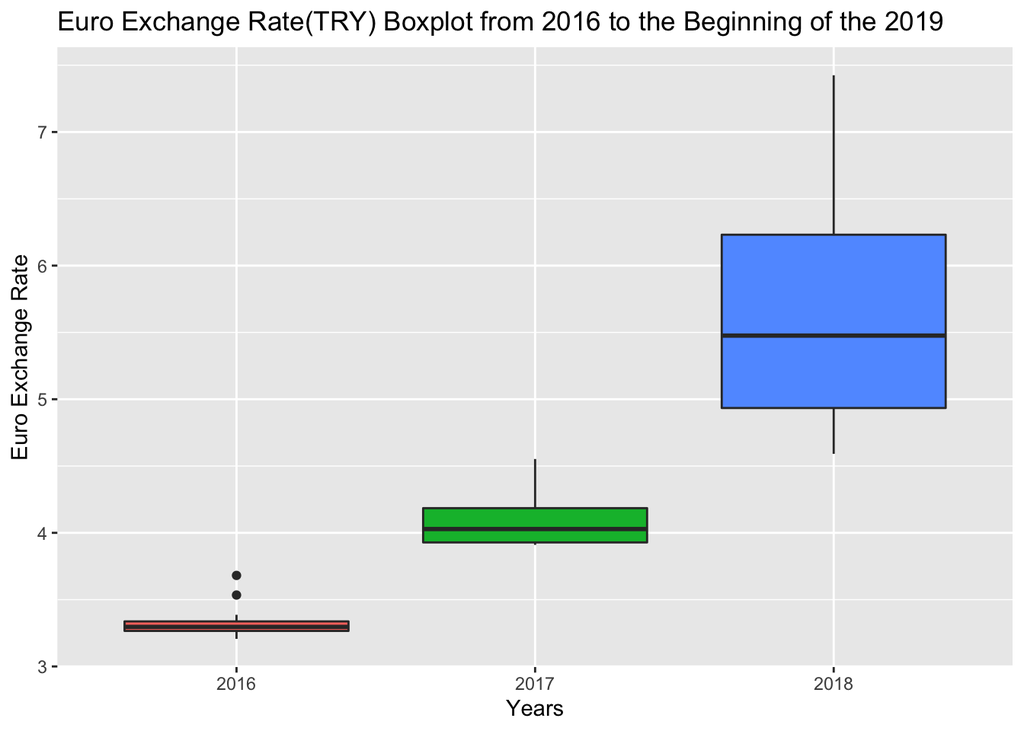

```r
ggplot(Euro_rate,aes(x=factor(year(Tarih)),y=values)) + geom_boxplot(aes(fill=factor(year(Tarih))))+
  xlab('Years') +
  ylab('Euro Exchange Rate') +
  ggtitle('Euro Exchange Rate(TRY) Boxplot from 2016 to the Beginning of the 2019') +
  theme(legend.position = 'None')
```

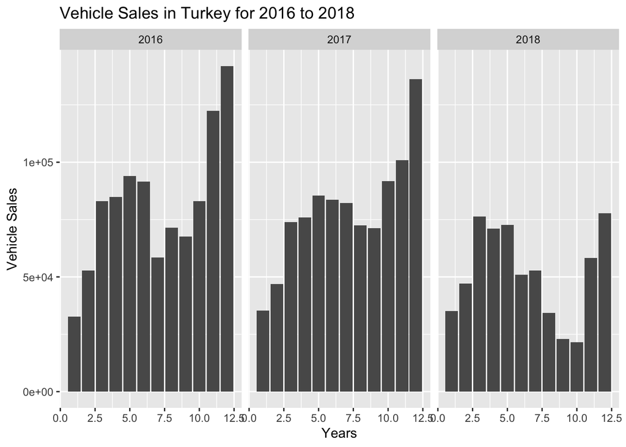

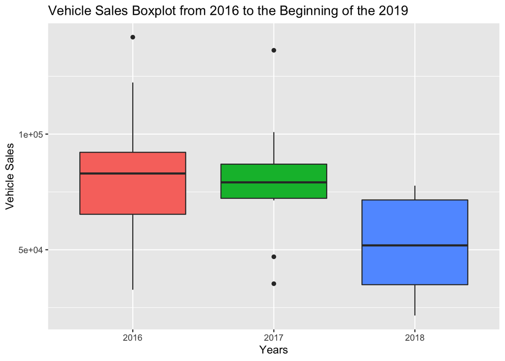

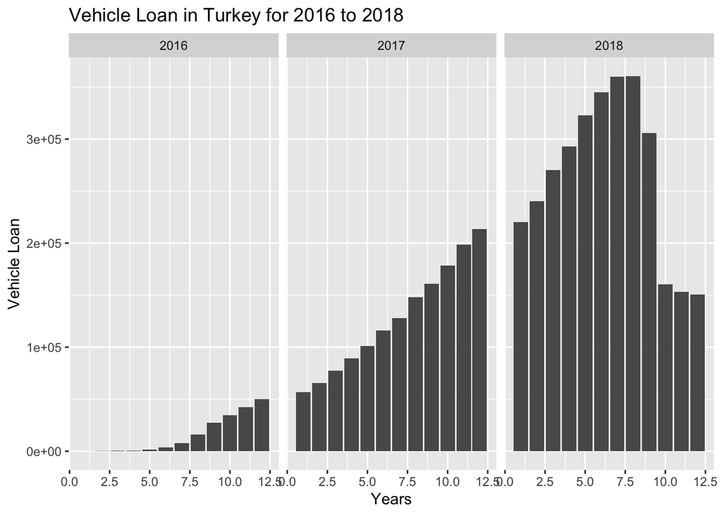

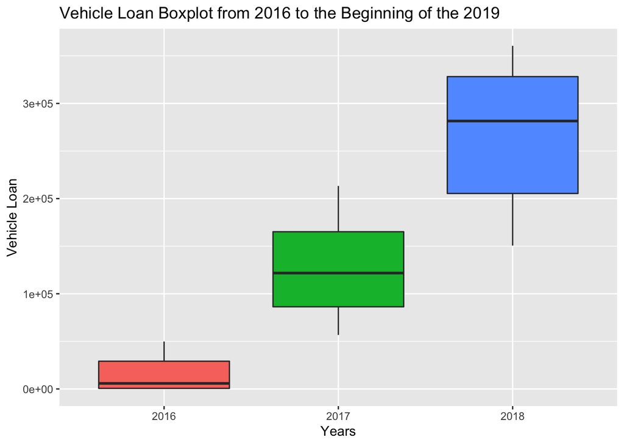

As mentioned below, banks provide speacial type of loans depending on customers’ necessity. The histogram above represent the amount of vehicle loan obtained by the people. Until Sepmteber 2018, there is an increasing trend. September 2018 is also the month at which sudden increase in Euro Exchange is occured.Since exchange rate affects the interest rates, increase of euro may cause intereset rate of vehicle loan to increase at the same time which also affects the people who plan to take a loan negatively. It can be seen from the boxplot that amount of vehicle loan taken by people changes at most 2018.

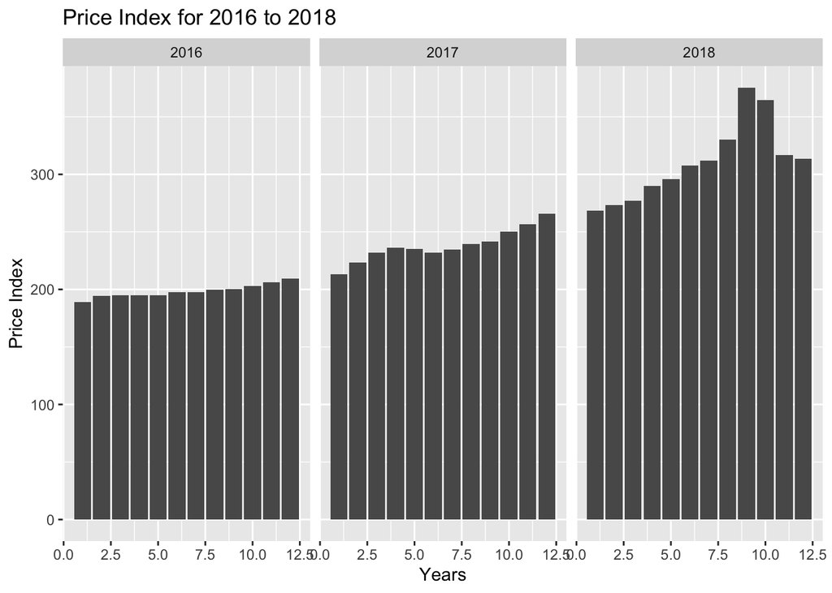

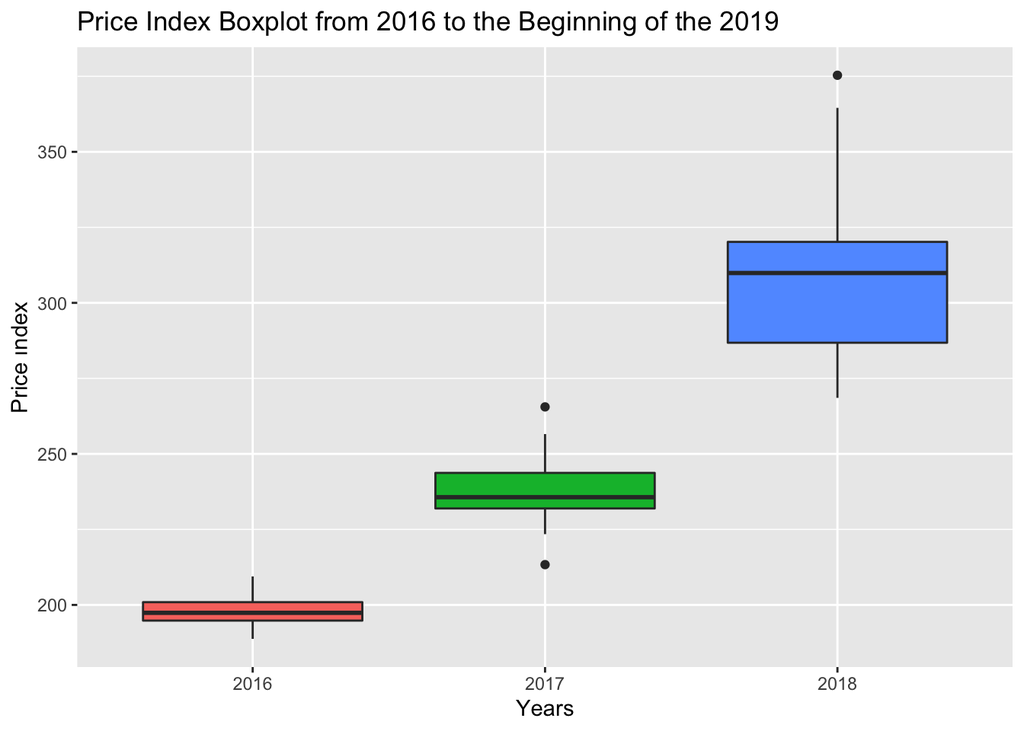

Price index is the measurement of the price changes in the given product at given periods. In the histogram, increasing trend of the vehicle price level can be seen. On September 2018 there is an considerable increase in price level, which may be one the results of the Euro exchange rate increase. Since some of the vehicles are imported from abroad which makes their prices Euro indexed, the others which produced in Turkey is consists of parts which are also imported from different countries. In both cases, the price level of vehicles is affected by the exchange rate. Similar behaviour of the price index and vehicle credit can be also observed by looking at their histograms. Till 09.2018 both of them keeps increasing, after that months, they both start decreasing. Reason might be the following, increasing price level of vehicles obliges people to get money support and vehicle loan is one of the limited money support options.

### CORRELATION

Correlation values are printed and plotted in a graph to show visulization of the interpretation that have been done in the above comments.

[figure not shown]

[output not shown]

```
##
##  Pearson's product-moment correlation
##
## data:  Vehicle_sale$values and Vehicle_loan$values
## t = -1.6327, df = 34, p-value = 0.1118
## alternative hypothesis: true correlation is not equal to 0
## 95 percent confidence interval:
##  -0.54949899  0.06461841
## sample estimates:
##        cor
## -0.2696417
```

Since the p-value is higher then the other test p-value, rejection of no correlation hypothesis would not be the best decision. The convenient explanation of this situation might be the fact that sales amount depends on other factors that have higher effect.

```
## [1] "Correlation Test between Number of Vehicles Sold and Price Index over 2016-2019"
```

```
##
##  Pearson's product-moment correlation
##
## data:  Vehicle_sale$values and Price_index$values
## t = -2.68, df = 34, p-value = 0.01127
## alternative hypothesis: true correlation is not equal to 0
## 95 percent confidence interval:
##  -0.6561327 -0.1032511
## sample estimates:
##        cor
## -0.4176205
```

```
## [1] "Correlation Test between Number of Vehicles Sold and Euro Exchange Rate over 2016-2019"
```

```
##
##  Pearson's product-moment correlation
##
## data:  Vehicle_sale$values and Euro_rate$values
## t = -2.8621, df = 34, p-value = 0.007153
## alternative hypothesis: true correlation is not equal to 0
## 95 percent confidence interval:
##  -0.6718996 -0.1310679
## sample estimates:
##        cor
## -0.4406299
```

```
## [1] "Correlation Test between Euro Exchange Rate and Price Index over 2016-2019"
```

```
##
##  Pearson's product-moment correlation
##
## data:  Price_index$values and Euro_rate$values
## t = 35.504, df = 34, p-value < 2.2e-16
## alternative hypothesis: true correlation is not equal to 0
## 95 percent confidence interval:
##  0.9740130 0.9932969
## sample estimates:
##       cor
## 0.9867808
```

```
## [1] "Correlation Test between Euro Exchange Rate and Vehicle Loan over 2016-2019"
```

```
##
##  Pearson's product-moment correlation
##
## data:  Vehicle_loan$values and Euro_rate$values
## t = 7.6142, df = 34, p-value = 7.57e-09
## alternative hypothesis: true correlation is not equal to 0
## 95 percent confidence interval:
##  0.6296336 0.8902606
## sample estimates:
##       cor
## 0.7939376
```

```
## [1] "Correlation Test between Price Index and Vehicle Loan over 2016-2019"
```

```
##
##  Pearson's product-moment correlation
##
## data:  Vehicle_loan$values and Price_index$values
## t = 9.1058, df = 34, p-value = 1.214e-10
## alternative hypothesis: true correlation is not equal to 0
## 95 percent confidence interval:
##  0.7100492 0.9169708
## sample estimates:
##       cor
## 0.8421347
```

### GOOGLE TRENDS

[figure not shown]

[figure not shown]

Taşıt Fiyatı is a key word that is used by the potential customers and the certain customers. It can be observed that data is fluctuating, so there is not a trend. As can be seen from the histogram and boxplot, at 2018, there is not high fluctuating in the data and median has higher value compare to other two. Its reason may be the increase in vehicles prices. Ad prices increases people tend to know more about the current prices.

[figure not shown]

[figure not shown]

As previous keyword, in this keyword also, searching amount of this keyword is also fluctuating.For the 2018, there is decrease in the mean value, which may be result of increasing prices of vehicle.

[figure not shown]

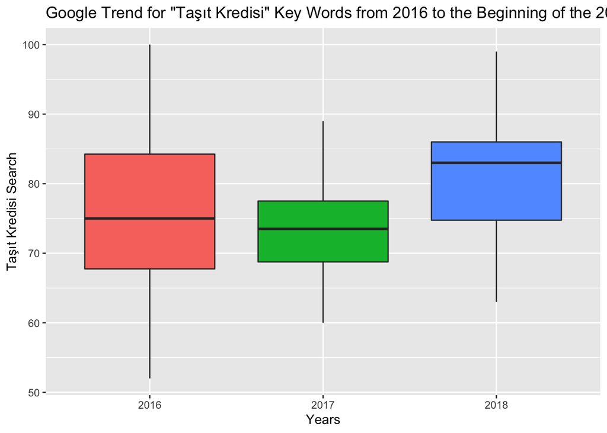

Taşıt kredisi search does not fluctuate as much as previous two keywords. As Euro exchange rate increases, price index increases which leads people to search more about vehicle loans. Since loan is a solution for high price level, people follow loan opportunities more to be able to afford high price level.

```
##   Euro_rate Price_index Vehicle_sale Vehicle_loan google_taşıt_kredisi
## 1  3.266920      188.76        32713           29                   52
## 2  3.262800      194.28        52825          262                   68
## 3  3.206348      194.79        82948          299                   67
## 4  3.213405      194.82        84887          683                   77
## 5  3.314733      195.09        93904         1438                   85
## 6  3.277364      197.42        91540         3846                   73
##   google_taşıt_fiyatı google_taşıt_alma
## 1                  19                74
## 2                  58                18
## 3                  10                41
## 4                  37                44
## 5                  26                18
## 6                  58                71
```

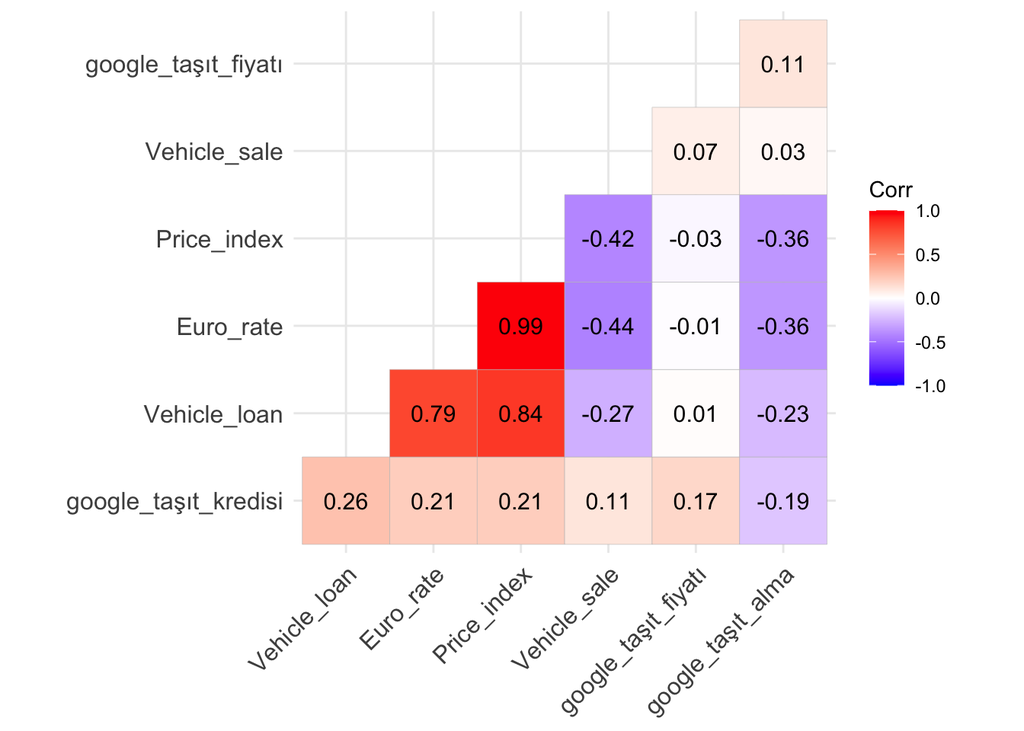

### CONCLUSION

The histograms and boxplot we got with the selected data sets helps us to visualize relationship between data sets. In this study, after looking at the behavior of the data sets, we realized that there is a strong correlation between Euro exchange rate, vehicle price index and vehicle loan. As expected, there is negative correlation between vehicle sale and price index. Surprisingly, the number of search for “vehicle sale” and actual vehicle sales is almost 0 correlated. One possible reason may be the fact that people do not incline to buy vehicles from web sites, therefore, who are buying vehicles may not prefer Google. Keyword sales price is also not correlated, almost 0. The amount of searches done by people for the keyword “vehicle loan” has not very high but positive correlation with Euro exchange rate, vehicle loan amount and vehicle sales amount.

It is also important to remember that while interpreting the relationship between data sets, there lots fo thing that we ignore.